# MNW

Rafał Gazda

19 grudnia 2018

Prace nad zadaniem zostaną rozpoczączęte od wgrania odpowiednich bibliotek, które będą wykorzystywane w dalszej częsci projektu, a także załadowanie danych z zewnętrznego pliku *DaneZ4.csv*.

Celem projektu jest wyestymowanie modelu za pomocą MNW, czyli metody największej wiarygodności. Wgrany zbiór zawiera 3 zmienne *y*, *x*, *x2*. Po wgraniu danych, które posiadają 1000 obserwacji muszę podzielić je w sposób losowy na dwie części - próbkę zawierającą 750 obserwacji, która wykorzystana zostanie do wyestymowania parametrów modelu (oznaczona u mnie jako *train*), a także podzbiór testowy zawierający 250 obserwacji (oznaczony u mnie jako *test*). Zgodnie z poleceniem do ustawienia ziarna wykorzystuje swój numer indeksu.

```r
set.seed(284095)
MyData = read.csv("C:/Users/Gazi/Desktop/Projekt 4 - R-studio/DaneZ4.csv", sep = ";", dec = ",")
```

# 1

Dane zostały podzielone na dwie grupy: pierszą 750-elementową, która jest zbiorem uczącym oraz na 250-elementową, która jest zbiorem testowym. Dla pierwszego zbioru policzono podstawowe statystyki.

```r
sample = sample(1:1000, 250, replace=FALSE)
sample
```

```
##   [1] 718 493 301 865 126 177 764  28 387 739 991 526 319  43 716 516 365
##  [18] 619 980 618 120 486 440 615 298 846 871 653 919 976 422  46 286 195
##  [35] 366 831 957 757 462 292 946 563 285 185 595 675 974 510 235 977 655
##  [52] 248 581 255  60   9 129  73 393 196 397 484 466 852 503 148 572 224
##  [69] 879 647 253  29 793 240  30 910 962 585  12 984 131 630 813 874 458
##  [86] 868 885 778 467  59 657 765 136 438 113 915 916 901 287 333 275 205
## [103] 223 343 334 646 394 166 209 160 176 678 790 800 463 208 864 947 474
## [120] 227 263 157 139 999 213 252  88 568 396 379 433   3 736 345 567  34
## [137] 169 507 316 280  97 931 102 367 156 688  32 469 395  95 722 640 421
## [154] 265 636 553  99 733 720 583 154 380 968 432 815 178 183 155 259 378
## [171] 808 262 779 221 780 149 945 706  16 358 446 803 738 180 532 571 487
## [188] 382  64 197 851 321 689 842 488 159 158 307 244 246 424 828 238 472
## [205] 777 955  14 151 536 351 359 664  68 381 848 531 707 201 407 123 944
## [222]  79 645 667 109 314 344 847 500 580 135 961 754 699 320  51 643 111
## [239] 481 807 662 256 913 403 496 390  37 291 331 610
```

```r
train = MyData[-sample,]
test = MyData[sample,]

res <-  lapply( train , function(x) rbind( mean = mean(x) ,
                                           sd = sd(x) ,
                                           median = median(x) ,
                                           minimum = min(x) ,
                                           maximum = max(x) ,
                                           kurtosis = kurtosis(x),
                                           skewness = skewness(x),
                                           coeff = sd(x)/mean(x) * 100
))

data.frame(res)
```

```
##                    y           x           x2
## mean      6.47733333  3.88181272   4.72905008
## sd        2.64931023  2.68325403  19.24714230
## median    6.00000000  3.80732867   4.74304621
## minimum   0.00000000 -3.17113198 -53.60964111
## maximum  16.00000000 12.69581259  59.11550094
## kurtosis  0.08943287 -0.09549930   0.03299241
## skewness  0.37574367  0.08611373  -0.10931625
## coeff    40.90124888 69.12373746 406.99806446
```

```r
trainY = train$y
trainX1 = train$x
trainX2 = train$x2

par(mfrow=c(1,2))
```

Natępnie dla każdej zmiennej został stworzony wykres pudełkowy i histogram, będzie on służył do wizualnego sprawdzenia, czy dana zmienna ma rozkład normalny W przypadku tych danych wszystkie zmienne mają rozkład zbliżony do normalnego. Jednak jest to jedynie obserwacja wykresu, problem normalności zostanie dokładniej zbadany w dalszej części projektu za pomocą testu Shapiro-Wilka i zostanie zbadana tylko zmienna *y*, ponieważ ta zmienna jest zmienną objaśnianą. W przypadku gdy zmienna *y* nie miałaby rozkładu normalnego skutkowałoby to brakiem normalności rozkładu reszt, co łamałoby założenia MNK.

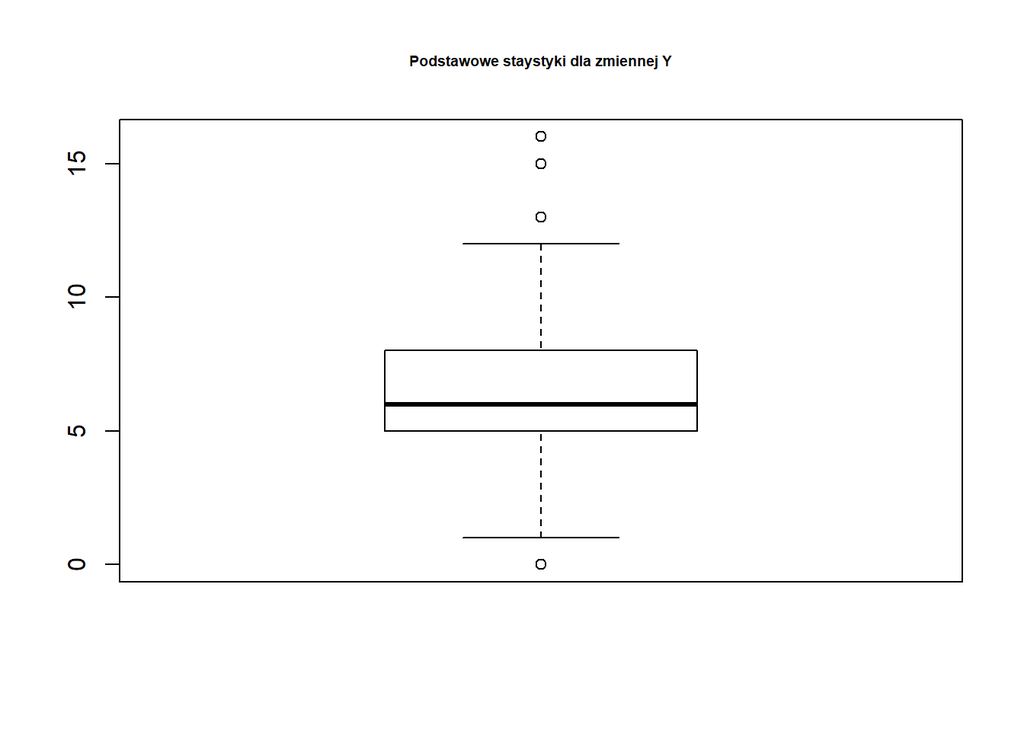

```r
# Charts for Y
boxplot(trainY, main = "Podstawowe staystyki dla zmiennej Y", cex.main=0.6)
```

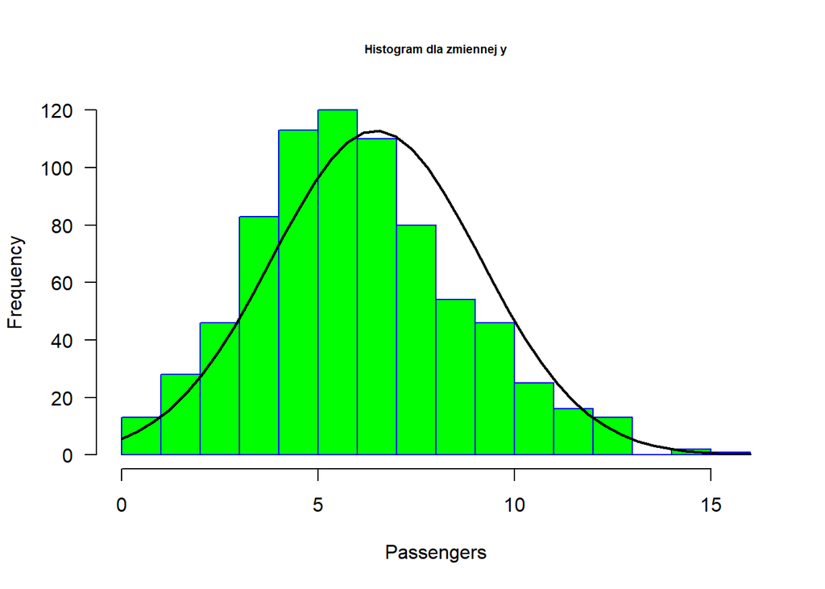

```r
h <- hist(trainY,
          main="Histogram dla zmiennej y",
          xlab="Passengers",
          border="blue",
          col="green",
          breaks=20,
          las=1,
          cex.main=0.6)

xfit <- seq(min(trainY), max(trainY), length = 40)
yfit <- dnorm(xfit, mean = mean(trainY), sd = sd(trainY))
yfit <- yfit * diff(h$mids[1:2]) * length(trainY)

lines(xfit, yfit, col = "black", lwd = 2)
```

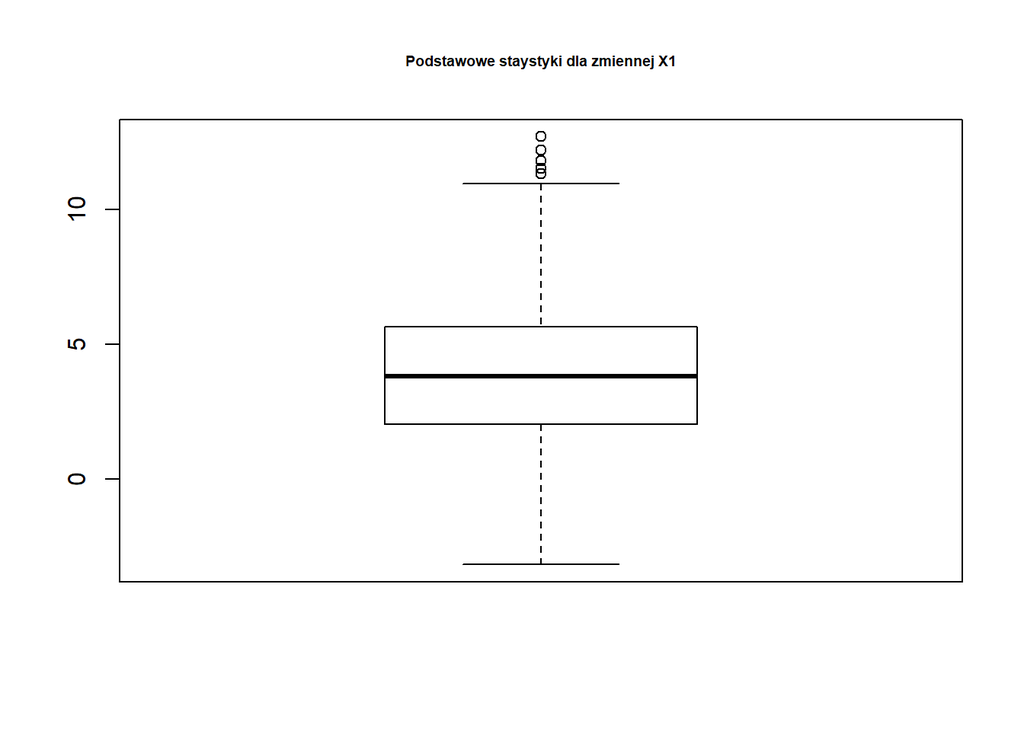

```r
# Charts for X1
boxplot(trainX1, main = "Podstawowe staystyki dla zmiennej X1", cex.main=0.6)
```

[figure not shown]

```r
h <- hist(trainY,
          main="Histogram dla zmiennej X1",
          xlab="Passengers",
          border="blue",
          col="green",
          breaks=20,
          las=1,
          cex.main=0.6)

xfit <- seq(min(trainX1), max(trainX1), length = 40)
yfit <- dnorm(xfit, mean = mean(trainX1), sd = sd(trainX1))
yfit <- yfit * diff(h$mids[1:2]) * length(trainX1)
lines(xfit, yfit, col = "black", lwd = 2)
```

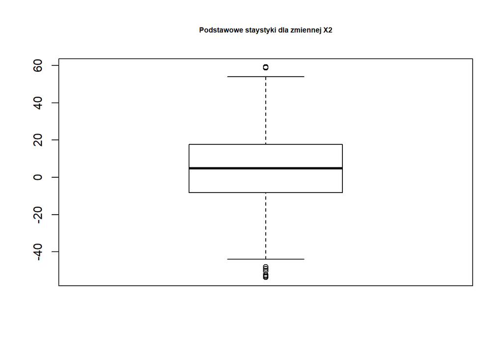

```r
# Charts for X2
boxplot(trainX2, main = "Podstawowe staystyki dla zmiennej X2", cex.main=0.6)
```

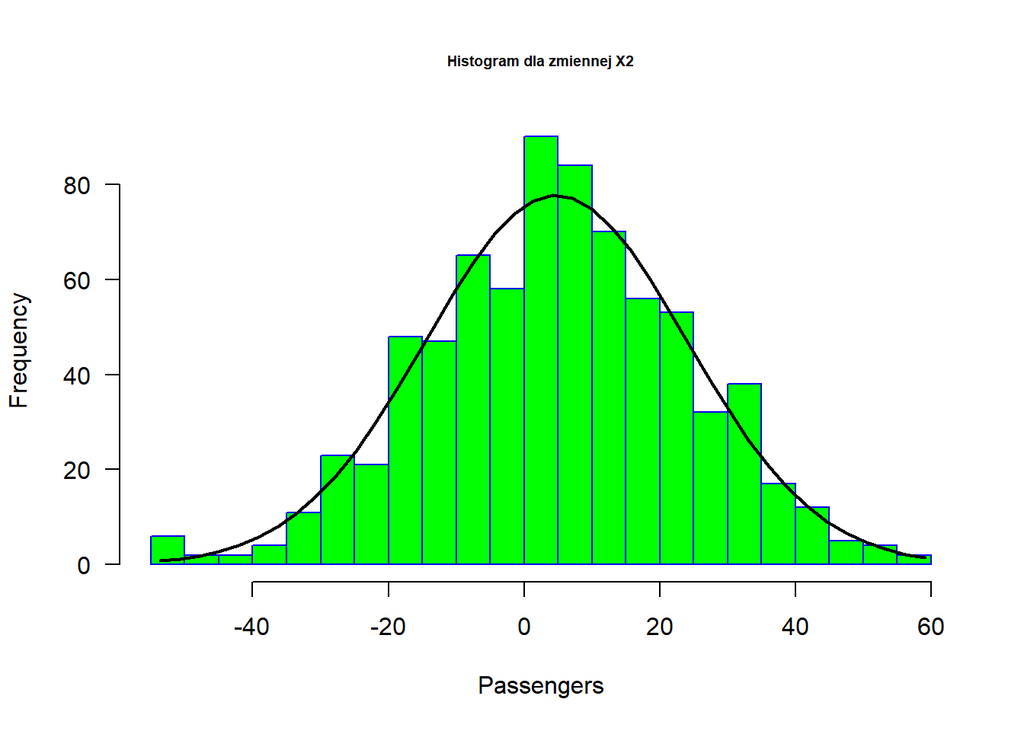

```r
h <- hist(trainX2,
          main="Histogram dla zmiennej X2",
          xlab="Passengers",
          border="blue",
          col="green",
          breaks=20,
          las=1,
          cex.main=0.6)
xfit <- seq(min(trainX2), max(trainX2), length = 40)
yfit <- dnorm(xfit, mean = mean(trainX2), sd = sd(trainX2))
yfit <- yfit * diff(h$mids[1:2]) * length(trainX2)
lines(xfit, yfit, col = "black", lwd = 2)
```